# MONITORING 2024 : PARCOURS D’ACCUEIL ET D’ACCOMPAGNEMENT DES PRIMO-ARRIVANTS ET DES PERSONNES ÉTRANGÈRES

Ainsi, **si la durée médiane des filières FLE s’approche de la durée maximale du parcours, celle de la filière Alpha la dépasse même de plus de 6 mois**.

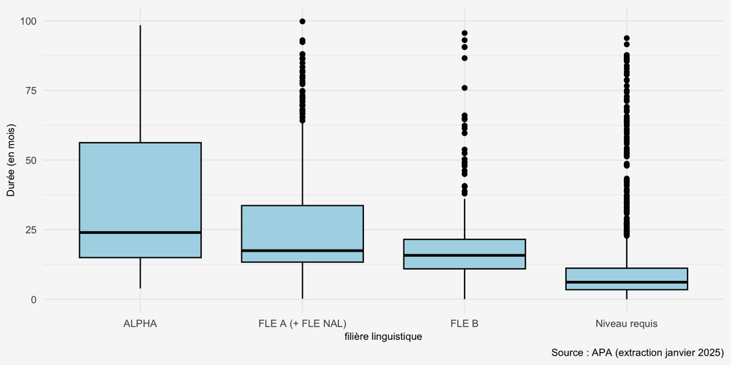

Figure 29: Distribution de la durée des parcours clôturés en 2024 selon la filière linguistique du bénéficiaire

| Filière linguistique | Effectif (n) | Propotion (%) | Médiane (mois) | Moyenne (mois) |
| --- | --- | --- | --- | --- |
| ALPHA | 200 | 7 | 24 | 38 |
| FLE A (+ FLE NAL) | 322 | 11 | 17 | 27 |
| FLE B | 320 | 11 | 16 | 20 |
| Niveau requis | 2185 | 72 | 6 | 10 |

Source : APA (extraction janvier 2025)

Table 7: Répartition des parcours clôturés en 2024 selon la filière linguistique du bénéficiaire

Toutefois, ces durées médianes par filière linguistique ont le double biais :

- de prendre en compte des bénéficiaires admis avant les réformes législatives de 2022 (obligation et élargissement), d’une part ;
- et de se baser uniquement sur celleux qui ont terminé leur parcours en 2024, alors qu’on pourrait faire l’hypothèse que ces dernier·ères sont les profils qui progressent le plus vite (surreprésentation des bénéficiaires avec un niveau requis par rapport à celleux qui suivent une formation linguistique) d’autre part.

Pour répondre (partiellement) à ces imperfections, nous avons calculé **un temps théorique de parcours** parmi les bénéficiaires ayant été admis depuis le 1er juin 2022, et qui ont soit terminé leur parcours en 2024, soit sont encore en train de suivre le parcours au 31 décembre 2024. Si cette durée théorique reste une sous-estimation (une grande partie de parcours non terminés), ce proxy permet de mieux approcher la réalité de terrain depuis les réformes législatives de 2022 en renforçant quantitativement (n=7 564) et qualitativement l’échantillon (meilleure représentativité des filières).

Les graphiques et tableaux basés sur ce temps théorique (Figure 30) illustrent ici aussi **un décalage important dans la durée médiane de parcours des personnes suivant une formation linguistique (au moins 11 mois) et celles qui ont le niveau requis au moment de l’inscription (au moins 7 mois).** Si la nouvelle législation (Ordonnance Cocom, 2023), en établissant un temps maximal de suivi du parcours, a pu lisser les temps de parcours par filière linguistique, il semble évident que ce “temps théorique” empêche aussi de voir précisément les différences entre filières linguistiques. Ce graphique permet néanmoins de montrer, à travers le mode statistique (la valeur-probabilité la plus élevée de chaque filière) que :

- d’une part, les bénéficiaires avec un niveau de langue requis ont la plus grande probabilité de terminer leur parcours après 4-5 mois ;
- d’autre part, il semble exister deux profils distincts parmi les bénéficiaires suivant une formation linguistique : un premier groupe, plus rapide, qui terminerait après 7-8 mois, et un second, moins rapide, qui terminerait après 15-16 mois.

Enfin, l’analyse des quartiles des durées de parcours par filières linguistiques donne également une information importante à garder à l’esprit (Table 8) : **près de 25% des bénéficiaires suivant une formation linguistique mettent au moins 1 an et demi (17-18 mois) pour réaliser leur parcours, alors qu’un quart des bénéficiaires avec un niveau requis mettent au moins 1 an**.

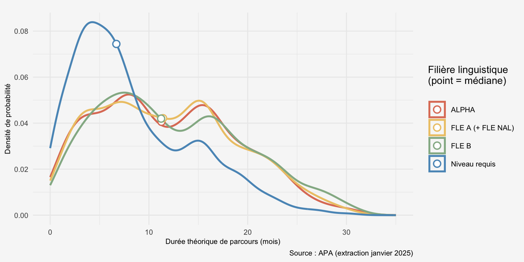

Figure 30: Distribution de la durée des parcours récents (dossiers admis depuis le 1er juin 2022) et clôturés en 2024 ou encore actifs au 31 décembre 2024, selon la filière linguistique.

| Filière linguistique | Effectif (n) | Propotion (%) | 1er quartile (mois) | Médiane (mois) | 3e quartile (mois) |
| --- | --- | --- | --- | --- | --- |
| ALPHA | 931 | 12 | 6 | 11 | 17 |
| FLE A (+ FLE NAL) | 1378 | 18 | 6 | 11 | 17 |
| FLE B | 1603 | 21 | 7 | 11 | 18 |
| Niveau requis | 3652 | 48 | 4 | 7 | 12 |

Source : APA (extraction janvier 2025)

Table 8: Répartition de la durée des parcours récents (dossiers admis depuis le 1er juin 2022) et clôturés en 2024 ou encore actifs au 31 décembre 2024, selon la filière linguistique.

| Catégorie de bénéficiaires | Effectif (n) | Propotion (%) | 1er quantile (mois) | Médiane (mois) | 3e quantile (mois) |
| --- | --- | --- | --- | --- | --- |
| Personne étrangère | 1762 | 23 | 5 | 7 | 13 |
| Primo-arrivant exempté (non obligé) | 1607 | 21 | 6 | 12 | 20 |
| Primo-arrivant obligé | 4195 | 55 | 4 | 9 | 15 |

Source : APA (extraction janvier 2025)

Table 9: Répartition de la durée de parcours théorique des dossiers admis depuis le 01/06/22 et clôturés en 2024 ou encore actifs au 31/12/24 selon la catégorie de bénéficiaires

Pour conclure, si les durées médianes (et moyennes) de parcours peuvent sembler assez courtes au regard de la durée maximale (18 mois), il convient de préciser deux éléments importants. D’une part, **les durées varient d’une catégorie de bénéficiaires à l’autre et d’une filière linguistique à l’autre**. Si les personnes étrangères réalisent leur parcours le plus rapidement, c’est aussi parce que la majorité de ces bénéficiaires ont le niveau de langue requis, ce qui amène à une durée médiane de 6-7 mois. A l’inverse, au moins un quart des bénéficiaires suivant une formation linguistique a une durée de parcours égale ou supérieure à la durée maximale (18 mois). Il faut considérer d’ailleurs que, **depuis les réformes législatives de 2022, ce sont surtout les bénéficiaires avec les profils les plus “rapides” qui sont sorti·es du parcours**, ce qui peut expliquer également ces temps relativement courts. Ainsi, en faisant l’hypothèse que les profils qui ont besoin de plus de temps tendent à représenter une part croissante du stock de dossiers actifs, il se pourrait que les durées médianes continuent d’augmenter dans les prochaines années.

### 5.3.3 Les abandons

Aujourd’hui, **les abandons de parcours pour les primo-arrivant·es sont quasiment inexistants** en grande partie en raison des sanctions. Toutefois, si on considère comme un abandon d’intégrer le parcours mais ne pas le faire aboutir, les seuls cas d’abandons concernent la perte du titre de séjour, ou encore des déménagements vers une autre région ou un autre pays.

En revanche pour les personnes étrangères (non prioritaires), diverses situations de vie peuvent influencer le non aboutissement de leur parcours d’accueil. Comme l’expose un des Bapas, ces situations peuvent soit favoriser leur intégration dans la société belge, soit entraîner un décrochage et un arrêt prématuré du parcours[^67].

Parmi les raisons d’abandon liées à une intégration réussie, on retrouve notamment le sentiment d’avoir acquis les connaissances nécessaires pour vivre de manière autonome, la priorité donnée à un emploi ou à une formation, ou encore la maîtrise du français acquis par d’autres moyens. Des contraintes personnelles, comme des responsabilités familiales importantes ou un déménagement, peuvent aussi expliquer certains arrêts.

À l’inverse, des facteurs liés au décrochage incluent la perte ou l’incertitude autour du titre de séjour, un retour dans le pays d’origine, des difficultés d’adaptation au dispositif d’accueil, ainsi que des problèmes de santé mentale nécessitant des soins importants.

Enfin, certains abandons sont d’ordre pédagogique : malgré un positionnement adapté, les formations ne correspondent pas toujours parfaitement aux besoins des bénéficiaires, ce qui peut compliquer leur suivi.

# 6 CONCLUSION

L’année 2024 a été marquée par **une saturation généralisée du dispositif.** Si la mise en place de la liste d’attente a permis de **réduire de 15% le flux des admissions** par rapport à 2023, le nombre de dossiers actifs a néanmoins augmenté de 7%, enregistrant **un niveau record de 6.013 au 31 décembre 2024.** Parallèlement, le **nombre de dossiers suspendus a doublé** et le volume de personnes **en liste d’attente a triplé** en un an. Le passage du BAPA Convivial en catégorie IV a certes permis de résorber une partie de la demande, notamment des personnes étrangères, mais n’est pas suffisante pour répondre à celle-ci.

Aussi, la part du public ayant un niveau de langue requis a augmenté notablement depuis les réformes de 2022, notamment chez les personnes étrangères, permettant de raccourcir la durée du parcours et contribuant à augmenter les sorties. Néanmoins, malgré l’augmentation du nombre de formations citoyennes cette année, les Bapas semblent avoir atteint leur plafond opérationnel compte tenu du budget actuellement alloué pour celles-ci. **Le nombre de FOCI par an est insuffisant pour désengorger le dispositif ou faire significativement baisser les listes d’attente.**

Parallèlement, une proportion importante des bénéficiaires reste en demande réelle de formations linguistiques. Alors que certaines filières linguistiques sont saturées. Ce qui a des conséquences sur les temps d’attentes entre deux modules ou en début de module, impactant tant l’apprentissage des bénéficiaires que la durée de leur Parcours d’accueil.

Face à cette situation, les **Bureaux d’accueil sont soumis à une pression croissante**, **sans perspective d’apaisement à court terme**. En effet, le report de charge d’une année à l’autre et le rythme d’entrée ne permettent ni de stabiliser le dispositif, ni de réduire les listes d’attente. Au contraire, les tendances des flux à la fin 2024 laissent penser que la saturation s’étendra aussi aux publics prioritaires. En 2025, il sera important en 2025 d’évaluer les flux de ces derniers.

Ensuite, l’inflation des tâches administratives liées à l’obligation, due en grande partie à la production d’attestations et à la gestion avec les administrations communales, notamment des suspensions, a réduit le temps effectivement consacré à l’accompagnement social, fragilisant ainsi cette composante du Parcours d’accueil.

En ce qui concerne les bénéficiaires, leurs profils sont très similaires à ceux observés en 2023. Les réformes de 2022 ont entrainé une diversification des publics, avec, d’une part des bénéficiaires disposant de niveaux socio-économiques et linguistiques relativement élevés, et, d’autre part, des bénéficiaires en situation de grande précarité, confrontés à des réalités complexes et présentant des besoins importants.

## Footnotes

[^1]: Depuis l’entrée en vigueur de l’obligation de suivi du parcours (juin 2022), l’APA interagit directement avec l’application BruWelcome développée par la COCOM et gérée par les communes en vue de suivre les primo-arrivant·es soumis·es à l’obligation.
[^2]: En 2024, certains écarts peuvent apparaître en raison de rectifications ou d’évolutions dans le calcul de certains indicateurs qui seront spécifiés à la fin de cette partie. Ces ajustements font suite à des réunions et des entretiens menés dans le cadre de la recherche 2025, et ont d’ores et déjà été intégrés dans le présent exercice de monitoring.
[^3]: Ce bug informatique est en cours d’analyse par le service informatique.
[^4]: Cf. “*L’obligation dans un contexte d’élargissement du public du Parcours d’accueil. Analyse d’une transition*.” Rapport de recherche de 2024, CBAI.
[^5]: Les autres critères sont : le caractère temporaire du séjour (moins d’un an), la fonction de diplomate, le fait d’avoir séjourné légalement et durablement au sein d’un pays de l’UE27+ (et avoir rempli les conditions d’intégration), le fait de composer un ménage avec un ressortissant de l’UE27+, la reconnaissance d’une maladie ou d’un handicap, la possession d’un autre certificat d’intégration, l’inscription précédente dans une autre commune/région où on a été dispensé de Parcours d’accueil, et la reconnaissance d’un certificat d’études organisé par une des trois Communautés belges.
[^6]: Dans le cadre de ce monitoring, nous n’avons pas trouvé nécessaire de faire une demande plus spécifique à l’échelle de la RBC. Le cas de la Belgique illustre en effet en premier lieu la situation bruxelloise.
[^7]: Selon les données de l’IBSA au 1<sup>er</sup> janvier 2024. Ici une personne étrangère est définie comme une personne n’ayant pas la nationalité belge au 1/01/2024 tout âge confondu.
[^8]: Juridiquement, il serait plus exact de parler de cartes et de documents de séjour, car aucun « titre de séjour n’est délivré aux citoyens de l’UE. Par facilité de langage, le terme « titre de séjour » est utilisé par Myria pour désigner à la fois les citoyen·nes de l’UE et les citoyen·nes non-européen·nes.
[^9]: Cette forte croissance depuis deux ans s’explique par la guerre que l’État d’Israël mène dans le territoire palestinien depuis octobre 2023.
[^10]: Le quotient de localisation est un coefficient de spécificité qui se calcule par le rapport entre la proportion de PA extra-européen·nes (hors-UE27+) sur l’ensemble des PA d’une commune et cette même proportion à l’échelle régionale. Si le coefficient est supérieur à 1 alors la commune se caractérise par une présence plus importante de PA extra-européen·nes (potentiellement obligé·es) qu’en moyenne en RBC. Au contraire, s’il est inférieur à 1 celle-ci, se caractérise par une présence moindre de ce public. S’il est égal à 1, la répartition est similaire à celle de l’ensemble de la Région.
[^11]: Pour plus d’information sur cette géographie (ségrégation) résidentielle particulière, voir le Focus n°21 de l’IBSA (2017) :https://ibsa.brussels/sites/default/files/publication/documents/FOCUS-21-FR-final.pdf
[^12]: Voir l’article de G. Van Hamme, T. Grippa et M. Van Criekingen (2016). “Mouvements migratoires et dynamiques des quartiers à Bruxelles” : https://journals.openedition.org/brussels/1331#tocto1n3. Dans cet article, outre le fait que les quartiers populaires centraux (dudit “croissant pauvre”) sont des quartiers d’accueil de l’immigration internationale des pays pauvres et intermédaires, ils montrent également que “les populations quittant les secteurs statistiques les plus pauvres de la ville [dudit”croissant pauvre”] s’installent en grande majorité dans les territoires intermédiaires adjacents dans l’ouest de la Région. […]. Ce processus est très certainement à l’origine de la détérioration presque généralisée des indices socio-économiques dans les secteurs statistiques socialement intermédiaires de la partie ouest de la ville. On assiste donc à un processus d’extension spatiale de la pauvreté vers l’ouest.”
[^13]: Si ces dossiers créés, mais non admis, étaient avant 2023 essentiellement dûs à des non-admissions (en particulier, liée à une durée de séjour de plus de 3 ans), ces derniers sont essentiellement des dossiers “en attente” d’inscription depuis l’élargissement du public aux Personnes étrangères. En effet, en crééant un dossier dans un Bapa spécifique, le bénéficiaire est affecté à ce Bapa pendant 3 mois (6 mois en 2025) afin d’éviter des inscriptions sur la liste d’attente d’opérateurs différents.
[^14]: Le taux de surpopulation est calculé comme le rapport de la liste d’attente (826 personnes) sur la capacité maximale du dispostif (6.000 places), qui est également le stock de dossier actifs au 31 décembre 2024.
[^15]: Le taux d’exclusion du public non-prioritaire est calculé comme le rapport entre l’effectif en liste d’attente à la fin de l’année 2024 et l’addition de l’effectif de public non-prioritaire admis durant l’année 2024 et de celui de la liste d’attente à la fin de l’année 2024.
[^16]: En effet, les réponses à l’impressionnante croissance des admissions en 2023 (+161%) et des dossiers actifs (+70%) n’ont pu être mises en œuvre qu’à partir de l’année 2024, grâce notamment au passage en catégorie IV du BAPA Convivial.
[^17]: Au vu des approximations derrières ces calculs (variation des ETPs effectifs au cours de l’année), nous avons arrondi ces chiffres à la dizaine.
[^18]: II convient de noter qu’il s’agit d’une estimation et que les cadences peuvent varier d’un BAPA à l’autre. Nous avions d’abord calculé **564 heures de FOCI par formateur·trice données en 2024**, ce qui représentait **plus de 9 FOCI de 60 heures par an** ou **11 FOCI par an** par formateur·trice.  
    Cependant, ce calcul comprenait **17 modules donnés par des organismes externes**.  
    Lors du focus group mené avec les formateur·trices dans le cadre du Rapport de Recherche de 2024 du CBAI, il était ressorti qu’en moyenne, les formateur·trices réalisaient **11 FOCI de 50 heures par an**.
[^19]: Pour une analyse approfondie des effets des réformes législatives de 2022 sur la charge de travail des Bapas, voir le Rapport de recherche 2024 du CBAI.
[^20]: Cf. Rapports d’activités de 2024 des Bapas. Une augmentation de 17% par rapport à 2023 et en cinq an une agumentation de 176%.
[^21]: Cf. Rapport d’activités 2024, VIA, p13.
[^22]: Cf. Rapport d’activités 2024, Convivial, p12
[^23]: En raison de son déploiement en urgence, le développement informatique de la liste d’attente a été conçu avant tout comme un outil de gestion, et non un outil de suivi. Par conséquent, la collecte de données n’est pas suffisamment robuste pour fournir une représentation complète de la situation ; elles constituent plutôt une (sous)estimation par rapport à la réalité observée sur le terrain.
[^24]: Rapport d’activités 2024, BAPA-BXL, p.10, Rapport d’activités 2024, Convivial, p.8.
[^25]: Cf. Rapport d’activités 2024, BAPA-BXL, p.10.
[^26]: Cf. Rapport d’activités 2024, VIA, p.5
[^27]: Cf. Rapport d’activités 2024, Convivial, p.7 ; Rapport d’activités 2024, VIA, p10
[^28]: Les motifs de suspension sont inconnus pour les primo-arrivant·es pour lesquel·les il faut une validation de la commune.
[^29]: Pour rappel, une personne admise dans le parcours est une personne qui répond aux critères pour effectuer le parcours, et dont le Bapas accepte de prendre en charge.
[^30]: *Le bilan social “est effectué à partir des informations communiquées par le bénéficiaire, notamment, à propos de sa situation familiale, professionnelle, socio-économique, relationnelle, de formation, de santé, de handicap et de ses conditions de logement.” (Art12, Arrêté COCOM 2024)*
[^31]: Il y a 16 bénéficiaires pour lesquel·les le genre est inconnu soit 0,3 % du public. Aucun·e bénéficiaire n’est identifié dans la catégorie “Autre” en 2024. BAPA-BXL exprime recevoir des personnes ne s’identifiant ni comme homme ou femme qui ne sont pas resencé·es par la difficulté à modifier le genre dans les documents d’identités (Rapport d’activité 2024, BAPA-BXL, p. 16).
[^32]: La proportion élevée de situations familiales inconnues est due à des bilans sociaux pas encore réalisés et en moindre mesure, à des données incomplètes qui ne permettent pas de classer des individus dans des catégories précises.
[^33]: Cf. “*L’obligation dans un contexte d’élargissement du public du Parcours d’accueil. Analyse d’une transition.*”, Rapport de recherche 2024, CBAI.
[^34]: Cet indicateur présente un taux de données manquantes de 19 %. Parmi celles-ci, 77 % (soit 801 bénéficiaires) s’expliquent par l’absence de bilan social établi au 31/12/2024. Le reste est imputable à un manque d’information sur la plateforme APA. Nous avons choisi d’inclure ces données dans l’analyse car l’augmentation du taux des données manquantes peut être symptomatique de la saturation, un temps plus important entre l’inscription et le rendez-vous pour le BS. Ces mêmes problèmes se posent pour les indicateurs qui suivent.
[^35]: Pour ce public, des formations intensives pendant les congés scolaires sont également organisées (cf. Rapport d’activités 2024, Convivial, p.16)
[^36]: Cf. Rapport d’activités 2024, Convivial, p. 17
[^37]: Cf. Rapport d’activités 2024, Convivial, p. 18
[^38]: Cf. Rapport d’activités 2024, Convivial, p. 18
[^39]: Défini comme les personnes sans diplôme suffisant pour répondre aux exigences du marché de l’emploi, on considère ici les personnes : sans diplômes, diplômées de l’enseignement primaire ou du secondaire inférieur.
[^40]: *Selon les données de Myria de 2022, le regroupement familial a augmenté de 37 % par rapport à 2020.*
[^41]: Les séjours limités concernent les cartes A, orange et les annexes 15, 19 et 19ter. Les séjours illimités (5 ans) concernent les cartes B, C, D, E, E+, F, F+.
[^42]: Cf. Rapport d’activités 2024, Convivial, p.20 ; Rapport d’activités 2024, BAPA-BXL, p.20
[^43]: A partir de 2024, cinq communes d’implantation des Bapas existent, grâce à l’ouverture de l’antenne de Convivial à Anderlecht.
[^44]: Cf. Rapport d’activités 2024, Convivial, p.22
[^45]: Pour plus d’informations, voir l’article de G.Van Hamme**,** T.Grippaet M.Van Criekingen, « Mouvements migratoires et dynamiques des quartiers à Bruxelles », *Brussels Studies* [En ligne], Collection générale.
[^46]: Comme dit dans la partie méthodologie, des ajustements ont été apportés dans le calcul du nombre de bilans sociaux réalisés en 2024, à la suite des entretiens menés avec les Bapas dans le cadre de notre recherche 2025 et des échanges en réunion APA. Certains bilans sociaux n’étaient pas datés mais contenaient des informations, nous avons donc décidé de les comptabiliser lorsqu’ils concernaient des personnes admises en 2024. Par conséquent, un écart de 54 bilans sociaux existe entre les données initialement transmises aux Bapas et ceux du monitoring.
[^47]: Cf. Rapport d’activités VIA, 2024, p.14
[^48]: Cf. Rapport d’activités BAPA-BXL, p31; p47, 2024
[^49]: Cf. Rapport d’activités VIA, p.31, 2024
[^50]: Ici on considère les modules arabes : les modules d’arabe oriental (14 %), d’arabe classique (5 %) et d’arabe maghrébin (14 %).
[^51]: Cf. Rapport d’activités 2024, BAPA-BXL, p. 32.
[^52]: Voir rapport de recherche du CRAcs (2023) sur la pratique de l’orientation des bénéficiaires et sur la place du Parcours d’accueil dans le paysage de l’action publique en Région bruxelloise.
[^53]: Cf. Rapport de recherche du CBAI, 2024, p. 75.
[^54]: Cf. Rapport d’activités 2024, Convivial, p.36
[^55]: Cf.Rapport d’activités 2024, Convivial, p.31 et Rapport d’activités 2024, BAPA-BXL, p.36.
[^56]: VIA illustre cette problématique : “*nous avons actuellement un peu plus de 1.500 personnes actives dans le Parcours qui devront suivre un module de Citoyenneté pour terminer leur Parcours. Cela correspond à plus d’une année d’activité, sans compter les personnes qui continuent à s’inscrire.*” (Rapport d’activités 2024, VIA p.46.)
[^57]: En ne distinguant pas les différentes formes de l’arabe (classique, maghrébin, oriental, oriental alpha).
[^58]: Cf. Rapport d’activités BAPA-BXL, 2024, p. 47
[^59]: Cf. Rapport d’activités 2024, Convivial, p. 36.
[^60]: Cf. Rapport d’activités 2024, VIA, p.49
[^61]: Aucune notation formelle n’est attribuée à l’issue du module linguistique. Cependant, les compétences sont évaluées de manière non standardisée par les formateur·trices, en fonction du contenu dispensé durant les cours et permettant de déterminer si les acquis sont jugés suffisants pour suivre le module qui suit.
[^62]: Cf. Rapport d’activités 2024, de VIA, p50.
[^63]: Données présentées par la COCOF lors de la réunion annuelle Bapas-OLs-COCOF-COCOM le 10 juin 2025.
[^64]: Ici, une inscription ne concerne pas une personne mais le fait de s’inscrire à un module. Une personne peut donc être comptée plusieurs fois si elle a suivi plusieurs modules.
[^65]: Cf. Rapport d’activités 2024, VIA, p. 31.
[^66]: Un problème technique lié à l’évolution de l’Application Primo-arrivant nous empêche de calculer les périodes de suspension, et donc de les soustraire à la durée de parcours totale.
[^67]: Cf. Rapport d’activités 2024, de VIA, p.53.